# OaklandCrimeAnalyze

## Github地址：[DM-Homwork](https://github.com/VicenTYC/DM-Homework1)

```python
# Import modules
import numpy as np
import pandas as pd
import seaborn as sns
import bokeh as bk
import re
from bokeh.io import output_notebook, show
output_notebook()
%matplotlib inline
import matplotlib.pyplot as plt
```

#### 忽略无关警告

```python
# Ignore irrelevant warnings
import warnings
warnings.filterwarnings('ignore')
```

```python
# 设置整体绘图打印样式
%config InlineBackend.figure_format='retina'
sns.set()
plt.rcParams['figure.figsize'] = (11, 6)
plt.rcParams['axes.labelpad'] = 10
sns.set_style("darkgrid")
# sns.set_palette("Reds")
# sns.set_context("poster", font_scale=1.0)
```

# 1.引入和分析数据

### 分析Oakland Crime Statistics 2011 to 2016数据集，对六个csv文件，发现其数据结构基本一致，在12年和14年数据中拥有11个属性，其中一个为zipcode的无用属性，所以可以将这六个文件整合成一个dataframe。 使用Pandas库中的`read_csv()`方法加载CSV文件内容

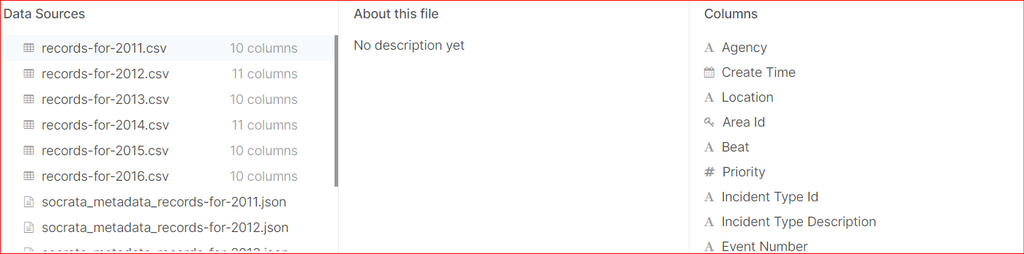

### Data Columns

- Agency
- Create Time
- Location
- Area Id
- Beat
- Priority
- Incident Type Id
- Incident Type Description
- Event Number
- Closed Time

```python
# 属性列表
column_names = ['agency', 'createTime', 'location', 'areaId', 'beat', 'priority',
       'incidentTypeId', 'incidentTypeDescription', 'eventNumber','closedTime']
```

```python
# 从CSV文件中读取数据, 并将时间属性值格式化
Crime11DF = pd.read_csv("F:/Data Mining/Oakland crime/oakland-crime-statistics-2011-to-2016/records-for-2011.csv", sep=",", header=0,
                        skip_blank_lines=True, parse_dates=['Create Time','Closed Time'])
Crime12DF = pd.read_csv("F:/Data Mining/Oakland crime/oakland-crime-statistics-2011-to-2016/records-for-2012.csv", sep=",", header=0,
                        skip_blank_lines=True, parse_dates=['Create Time','Closed Time'])
Crime13DF = pd.read_csv("F:/Data Mining/Oakland crime/oakland-crime-statistics-2011-to-2016/records-for-2013.csv", sep=",", header=0,
                        skip_blank_lines=True, parse_dates=['Create Time','Closed Time'])
Crime14DF = pd.read_csv("F:/Data Mining/Oakland crime/oakland-crime-statistics-2011-to-2016/records-for-2014.csv", sep=",", header=0,
                        skip_blank_lines=True, parse_dates=['Create Time','Closed Time'])
Crime15DF = pd.read_csv("F:/Data Mining/Oakland crime/oakland-crime-statistics-2011-to-2016/records-for-2015.csv", sep=",", header=0,
                        skip_blank_lines=True, parse_dates=['Create Time','Closed Time'])
Crime16DF = pd.read_csv("F:/Data Mining/Oakland crime/oakland-crime-statistics-2011-to-2016/records-for-2016.csv", sep=",", header=0,
                        skip_blank_lines=True, parse_dates=['Create Time','Closed Time'])
```

```python
# 调整列位置，并删除zipCode列
Crime12DF = Crime12DF[['Agency', 'Create Time', 'Location 1', 'Area Id', 'Beat', 'Priority',
       'Incident Type Id', 'Incident Type Description', 'Event Number','Closed Time']]
Crime14DF = Crime12DF[['Agency', 'Create Time', 'Location 1', 'Area Id', 'Beat', 'Priority',
       'Incident Type Id', 'Incident Type Description', 'Event Number','Closed Time']]
```

```python
Crime12DF
```

|  | Agency | Create Time | Location 1 | Area Id | Beat | Priority | Incident Type Id | Incident Type Description | Event Number | Closed Time |
| --- | --- | --- | --- | --- | --- | --- | --- | --- | --- | --- |
| 0 | OP | 2012-01-01 00:00:25 | {'human_address': '{"address": "OLIVE ST", "ci... | 2.0 | 32Y | 2.0 | 415GS | 415 GUNSHOTS | LOP120101000004 | 2012-01-01 00:40:27 |
| 1 | OP | 2012-01-01 00:00:27 | {'human_address': '{"address": "AV&MACARTHUR B... | 2.0 | 30Y | 2.0 | 415GS | 415 GUNSHOTS | LOP120101000003 | 2012-01-01 01:34:31 |
| 2 | OP | 2012-01-01 00:00:48 | {'human_address': '{"address": "SYCAMORE ST", ... | 1.0 | 06X | 2.0 | 949 | SUSPICIOUS VEHICLE | LOP120101000005 | 2012-01-01 01:18:38 |
| 3 | OP | 2012-01-01 00:00:58 | {'human_address': '{"address": "AV&MACARTHUR B... | 2.0 | 35X | 2.0 | 415GS | 415 GUNSHOTS | LOP120101000008 | 2012-01-01 02:37:00 |
| 4 | OP | 2012-01-01 00:01:14 | {'human_address': '{"address": "ST&WOOD ST", "... | 1.0 | 02Y | 2.0 | 415GS | 415 GUNSHOTS | LOP120101000007 | 2012-01-01 02:12:39 |
| ... | ... | ... | ... | ... | ... | ... | ... | ... | ... | ... |
| 187426 | OP | 2012-11-26 22:54:15 | {'latitude': '37.82844', 'longitude': '-122.27... | 1.0 | 25X | 1.0 | 211 | ROBBERY | LOP121126001022 | 2012-11-26 23:26:17 |
| 187427 | OP | 2012-11-29 04:04:54 | {'latitude': '39.442458', 'longitude': '-74.50... | 1.0 | 08X | 2.0 | SECCK | SECURITY CHECK | LOP121129000093 | 2012-11-29 04:44:04 |
| 187428 | OP | 2012-11-28 10:12:13 | {'latitude': '33.50162', 'longitude': '-101.84... | 2.0 | NaN | 2.0 | 273_5 | INFLICT INJURY ON SP | LOP121128000342 | 2012-11-28 10:22:21 |
| 187429 | OP | 2012-11-29 04:41:24 | {'latitude': '26.945458', 'longitude': '-82.35... | 2.0 | 31X | 2.0 | SECCK | SECURITY CHECK | LOP121129000099 | 2012-11-29 05:39:57 |
| 187430 | OP | 2012-12-08 18:28:42 | {'latitude': '35.442556', 'longitude': '-86.77... | NaN | NaN | 2.0 | SECCK | SECURITY CHECK | LOP121208000733 | 2012-12-08 18:56:18 |

187431 rows × 10 columns

# 2. 源数据清洗并合并

### 发现12年和14年数据的location属性的数据格式为dict数据类型，并且可能包含经纬度，所以从中提取和其他文件相同的值填充，即"address": 的值

```python
def extractAddress (x) :
    x = str(x)
    resGroup = re.search(r'address": "(.*?)"',x)
    if resGroup !=None:
        x = resGroup.group().replace('"',"").replace("address: ","")
    else:
        x = None
    return(x)
# 提取address信息并替换 Location 1 属性的值
Crime12DF['Location 1'] = Crime12DF['Location 1'].apply(extractAddress)
Crime14DF['Location 1'] = Crime14DF['Location 1'].apply(extractAddress)
```

```python
Crime12DF
```

|  | Agency | Create Time | Location 1 | Area Id | Beat | Priority | Incident Type Id | Incident Type Description | Event Number | Closed Time |
| --- | --- | --- | --- | --- | --- | --- | --- | --- | --- | --- |
| 0 | OP | 2012-01-01 00:00:25 | OLIVE ST | 2.0 | 32Y | 2.0 | 415GS | 415 GUNSHOTS | LOP120101000004 | 2012-01-01 00:40:27 |
| 1 | OP | 2012-01-01 00:00:27 | AV&MACARTHUR BLVD | 2.0 | 30Y | 2.0 | 415GS | 415 GUNSHOTS | LOP120101000003 | 2012-01-01 01:34:31 |
| 2 | OP | 2012-01-01 00:00:48 | SYCAMORE ST | 1.0 | 06X | 2.0 | 949 | SUSPICIOUS VEHICLE | LOP120101000005 | 2012-01-01 01:18:38 |
| 3 | OP | 2012-01-01 00:00:58 | AV&MACARTHUR BLVD | 2.0 | 35X | 2.0 | 415GS | 415 GUNSHOTS | LOP120101000008 | 2012-01-01 02:37:00 |
| 4 | OP | 2012-01-01 00:01:14 | ST&WOOD ST | 1.0 | 02Y | 2.0 | 415GS | 415 GUNSHOTS | LOP120101000007 | 2012-01-01 02:12:39 |
| ... | ... | ... | ... | ... | ... | ... | ... | ... | ... | ... |
| 187426 | OP | 2012-11-26 22:54:15 | 980&WB AV&MACARTHUR BLVD | 1.0 | 25X | 1.0 | 211 | ROBBERY | LOP121126001022 | 2012-11-26 23:26:17 |
| 187427 | OP | 2012-11-29 04:04:54 | 98TH/D ST&TELEGRAPH AV | 1.0 | 08X | 2.0 | SECCK | SECURITY CHECK | LOP121129000093 | 2012-11-29 04:44:04 |
| 187428 | OP | 2012-11-28 10:12:13 | 98TH | 2.0 | NaN | 2.0 | 273_5 | INFLICT INJURY ON SP | LOP121128000342 | 2012-11-28 10:22:21 |
| 187429 | OP | 2012-11-29 04:41:24 | 996A EDGEWATER DR | 2.0 | 31X | 2.0 | SECCK | SECURITY CHECK | LOP121129000099 | 2012-11-29 05:39:57 |
| 187430 | OP | 2012-12-08 18:28:42 | E AV AND BELFAST AV | NaN | NaN | 2.0 | SECCK | SECURITY CHECK | LOP121208000733 | 2012-12-08 18:56:18 |

187431 rows × 10 columns

## 2.1 接下来将6个数据文件，合并成一个数据集

### 首先统一化数据列名

```python
Crime11DF.columns = column_names
Crime12DF.columns = column_names
Crime13DF.columns = column_names
Crime14DF.columns = column_names
Crime15DF.columns = column_names
Crime16DF.columns = column_names
```

```python
# 按行将数据集合并成新Dataframe
CrimeDF = pd.concat([Crime11DF,Crime12DF,Crime13DF,Crime14DF,Crime15DF,Crime16DF])
# 重新建立索引
CrimeDF.reset_index(inplace=True,drop=True)
```

```python
print(len(CrimeDF))
print(len(Crime11DF)+len(Crime12DF)+len(Crime13DF)+len(Crime14DF)+len(Crime15DF)+len(Crime16DF))
```

```
1046339
1046339
```

```python
CrimeDF.info()
```

```
<class 'pandas.core.frame.DataFrame'>
RangeIndex: 1046339 entries, 0 to 1046338
Data columns (total 10 columns):
 #   Column                   Non-Null Count    Dtype
---  ------                   --------------    -----
 0   agency                   1046334 non-null  object
 1   createTime               1046334 non-null  datetime64[ns]
 2   location                 1046199 non-null  object
 3   areaId                   1040346 non-null  object
 4   beat                     1040767 non-null  object
 5   priority                 1046334 non-null  float64
 6   incidentTypeId           1046334 non-null  object
 7   incidentTypeDescription  1046087 non-null  object
 8   eventNumber              1046334 non-null  object
 9   closedTime               1046291 non-null  datetime64[ns]
dtypes: datetime64[ns](2), float64(1), object(7)
memory usage: 79.8+ MB
```

### 查看各个属性空值的个数

```python
# 每列空值的数目:
CrimeDF.isnull().sum()
```

```
agency                        5
createTime                    5
location                    140
areaId                     5993
beat                       5572
priority                      5
incidentTypeId                5
incidentTypeDescription     252
eventNumber                   5
closedTime                   48
dtype: int64
```

# 3.使用`.describe()` 函数来检查标称属性的概括信息

- **`count`** 列属性值的总数
- **`unique`** 不同数据值的数量
- **`top`** 频数最大的属性值
- **`freq`** 最大频数属性值对应的频数（众数）

### 并画出直方图

```python
# agency的概括信息
CrimeDF['agency'].describe()
```

```
count     1046334
unique          1
top            OP
freq      1046334
Name: agency, dtype: object
```

### agency属性只有一个值，即OP，频数为1046334

```python
# 犯罪事件开始时间createTime的概括信息
CrimeDF['createTime'].describe()
```

```
count                 1046334
unique                 856082
top       2013-01-29 09:16:31
freq                       18
first     2011-01-01 00:00:00
last      2016-07-31 23:57:31
Name: createTime, dtype: object
```

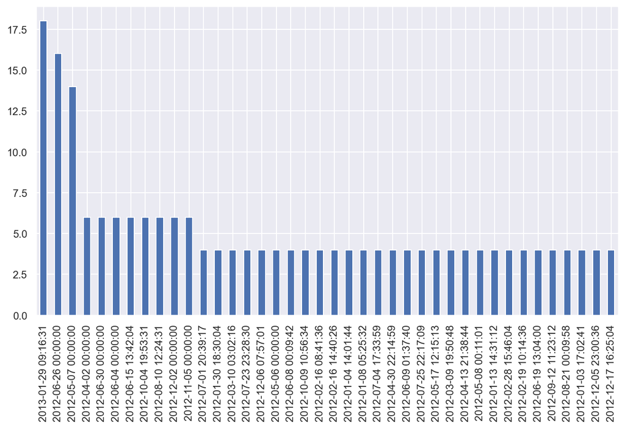

```python
CrimeDF['createTime'].value_counts().head(40).plot.bar()
```

```python
# 犯罪事件结束时间closedTime的概括信息
CrimeDF['closedTime'].describe()
```

```
count                 1046291
unique                 856323
top       2012-12-07 01:10:42
freq                        4
first     2011-01-01 00:02:28
last      2017-02-02 11:10:10
Name: closedTime, dtype: object
```

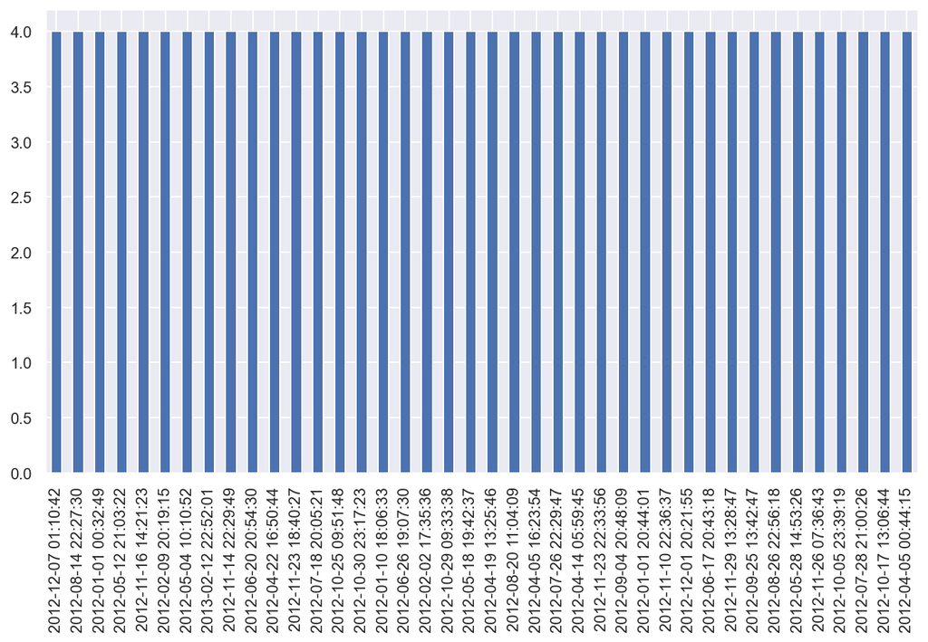

```python
CrimeDF['closedTime'].value_counts().head(40).plot.bar()
```

```python
# location的概括信息
CrimeDF['location'].describe()
```

```
count                     1046199
unique                     141095
top        INTERNATIONAL BLVD
freq                         9498
Name: location, dtype: object
```

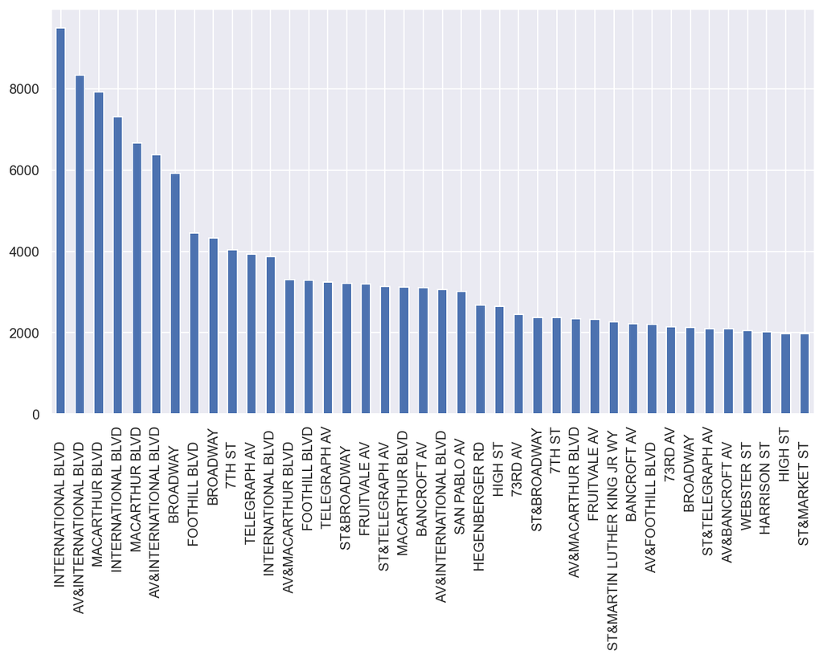

```python
CrimeDF['location'].value_counts().head(40).plot.bar()
```

```python
# areaId的概括信息
CrimeDF['areaId'].describe()
```

```
count     1040346.0
unique         11.0
top             1.0
freq       386474.0
Name: areaId, dtype: float64
```

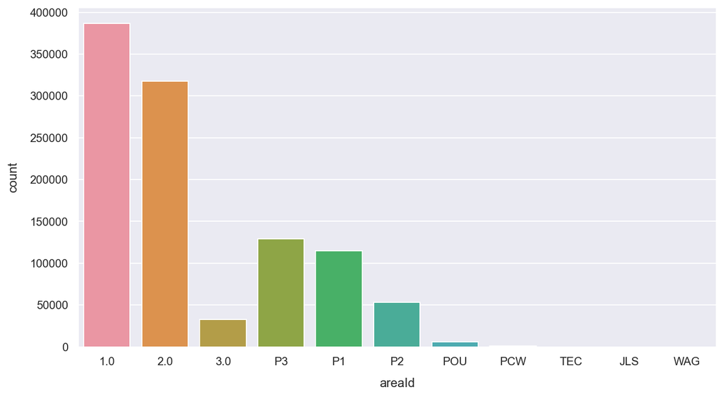

```python
# CrimeDF['areaId'].value_counts().plot.bar()
sns.countplot(CrimeDF['areaId'])
```

```python
# beat的概括信息
CrimeDF['beat'].describe()
```

```
count     1040767
unique         58
top           04X
freq        43846
Name: beat, dtype: object
```

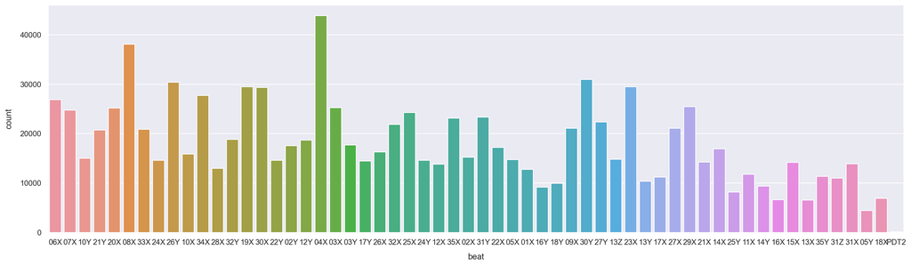

```python
plt.rcParams['figure.figsize'] = (22, 6)
sns.countplot(CrimeDF['beat'])
plt.rcParams['figure.figsize'] = (11, 6)
```

```python
# incidentTypeId的概括信息
CrimeDF['incidentTypeId'].describe()
```

```
count     1046334
unique        285
top          933R
freq        97914
Name: incidentTypeId, dtype: object
```

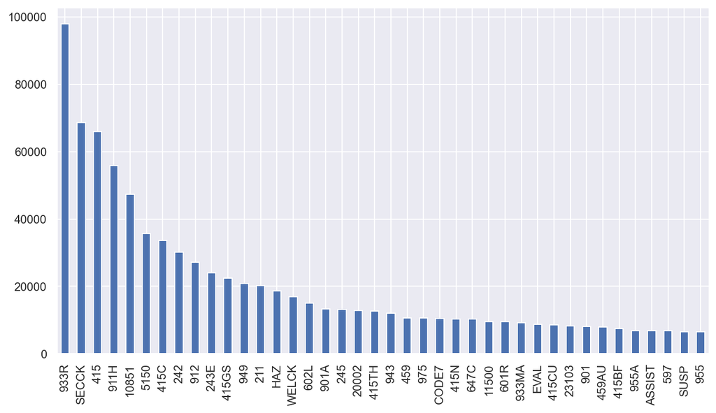

```python
CrimeDF['incidentTypeId'].value_counts().head(40).plot.bar()
```

```python
# incidentTypeDescription的概括属性
CrimeDF['incidentTypeDescription'].describe()
```

```
count          1046087
unique             286
top       ALARM-RINGER
freq             97914
Name: incidentTypeDescription, dtype: object
```

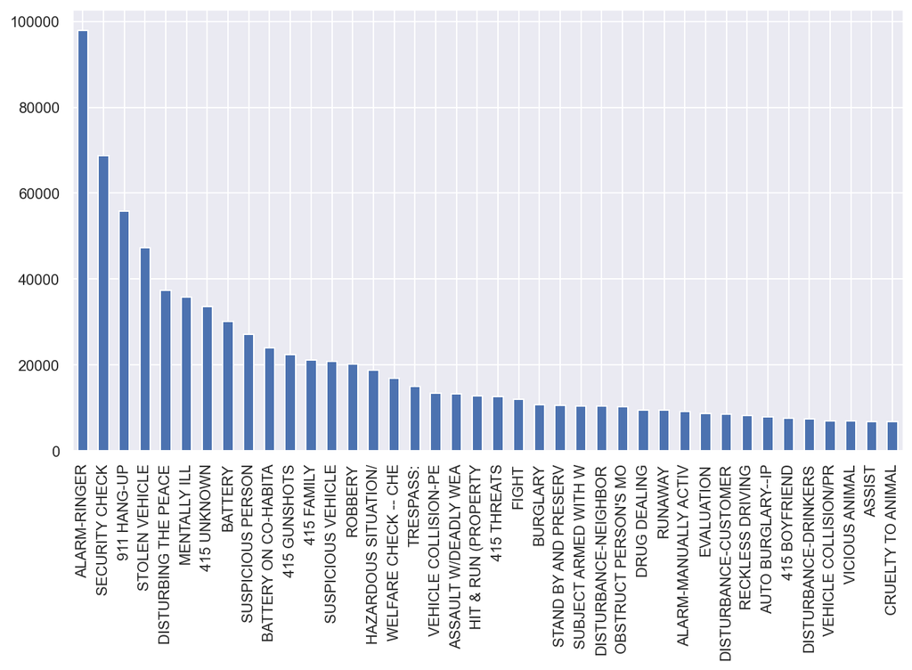

```python
CrimeDF['incidentTypeDescription'].value_counts().head(40).plot.bar()
```

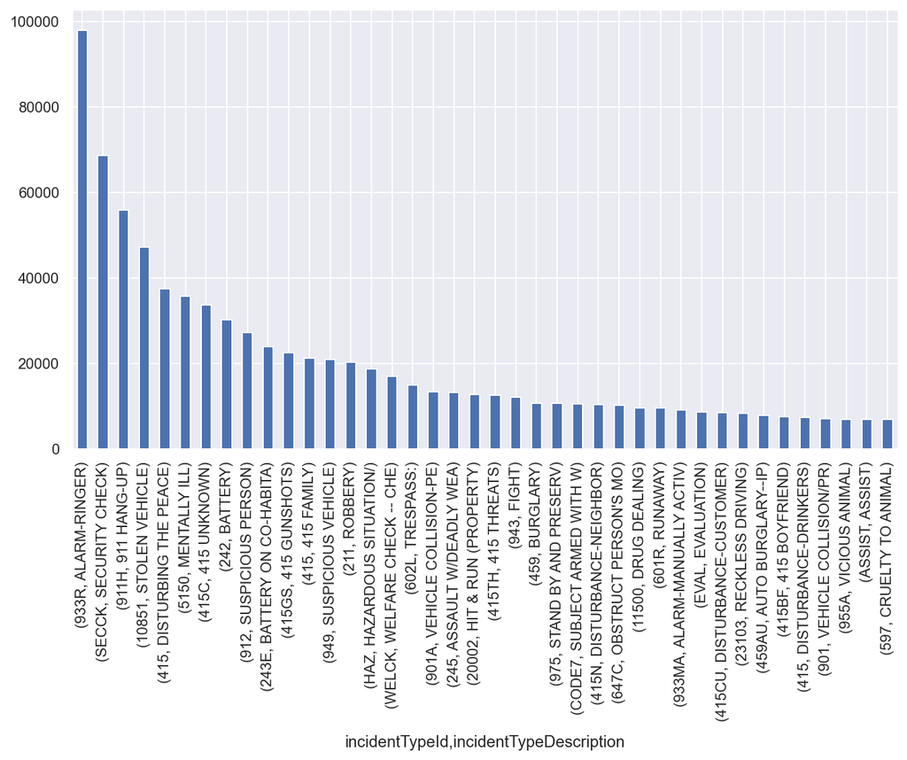

```python
CrimeDF.groupby(['incidentTypeId','incidentTypeDescription']).agg(np.size)['agency'].sort_values(ascending=False).head(40).plot.bar()
```

```python
# eventNumber的概括信息
CrimeDF['eventNumber'].describe()
```

```
count             1046334
unique             858904
top       LOP121114000964
freq                    2
Name: eventNumber, dtype: object
```

### 对于案件的编号应该是不允许重复的，所以对于重复的元组应该在数据清洗中删除

## 3.1 检查数值属性的概括信息

```python
# priority的概括信息
CrimeDF['priority'].describe()
```

```
count    1.046334e+06
mean     1.779475e+00
std      4.146563e-01
min      0.000000e+00
25%      2.000000e+00
50%      2.000000e+00
75%      2.000000e+00
max      2.000000e+00
Name: priority, dtype: float64
```

```python
# 查看优先级的频数分布（众数）
CrimeDF['priority'].value_counts()
```

```
2.0    815615
1.0    230695
0.0        24
Name: priority, dtype: int64
```

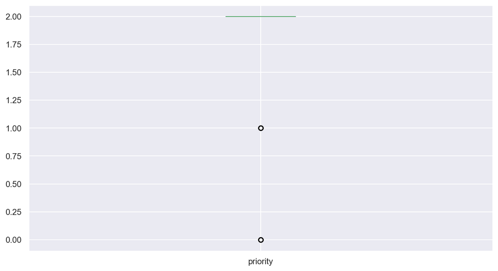

```python
# 绘制盒图
CrimeDF['priority'].plot.box()
```

# 4.接下来处理属性缺失值

## 4.1 剔除缺失部分

### 由以上分析得出，数据集中存在案件编号相同的元组，对于案件编号eventNumber而言，不允许重复，因此对重复数据进行剔除

```python
CrimeDF['eventNumber'].value_counts()
```

```
LOP121114000964    2
LOP120930001055    2
LOP120106000970    2
LOP120222000552    2
LOP121101001063    2
                  ..
LOP110615001210    1
LOP131104000901    1
LOP110501000173    1
LOP130728000751    1
LOP160513000156    1
Name: eventNumber, Length: 858904, dtype: int64
```

```python
# 查看相同编号案件
CrimeDF[CrimeDF['eventNumber']=='LOP120913000690']
```

|  | agency | createTime | location | areaId | beat | priority | incidentTypeId | incidentTypeDescription | eventNumber | closedTime |
| --- | --- | --- | --- | --- | --- | --- | --- | --- | --- | --- |
| 311214 | OP | 2012-09-13 16:20:28 | ST&WEBSTER ST | 1 | 08X | 2.0 | 647 | DISORDERLY CONDUCT: | LOP120913000690 | 2012-09-13 17:06:19 |
| 686697 | OP | 2012-09-13 16:20:28 | ST&WEBSTER ST | 1 | 08X | 2.0 | 647 | DISORDERLY CONDUCT: | LOP120913000690 | 2012-09-13 17:06:19 |

### 发现相同编号案件信息相同

### 4.1.1 处理相同编号案件

### 使用`drop_duplicate`函数剔除dataframe中指定列的重复元组

```python
print(len(CrimeDF))
```

```
1046339
```

```python
CrimeDF.drop_duplicates(subset ='eventNumber',keep='first',inplace=True )
```

```python
# 查看相同编号案件
CrimeDF['eventNumber'].value_counts().head(3)
```

```
LOP110720000127    1
LOP110520001119    1
LOP121202000415    1
Name: eventNumber, dtype: int64
```

```python
print(len(CrimeDF))
```

```
858905
```

### 4.1.2 同样对于createTime缺失的元组，因为只有一个条数据缺失，因此删除此元组

```python
# createTime 为空的元组数
CrimeDF.createTime.isnull().sum()
```

```
1
```

```python
# 删除空元组
CrimeDF.dropna(how="any", subset=["createTime"],inplace=True)
```

```python
# createTime 为空的元组数
CrimeDF.createTime.isnull().sum()
```

```
0
```

### 4.1.3 处理location属性缺失的元组

### 首先计算删除这些元组的影响

```python
# 计算如果location缺失元组删除后剩余数据的比例
total_records = len(CrimeDF)
missing_location= CrimeDF["location"].isnull().sum()
missing_ratio = 100 - ((missing_location / total_records) * 100)
print("Missing location: {}".format(missing_location)+ "\n" +
      "Total records: {}".format(total_records) + "\n" +
      "Percentage remaining: {:.4f}%".format(missing_ratio))
```

```
Missing location: 69
Total records: 858904
Percentage remaining: 99.9920%
```

### 可以看到删除这些元组后我们仍可以获得99.9920%的数据，不影响后续的分析

```python
# 删除空元组
CrimeDF.dropna(how="any", subset=["location"],inplace=True)
```

### 4.1.4 同样的操作处理areaId属性缺失的元组

### 首先计算删除这些元组的影响

```python
# 计算如果location缺失元组删除后剩余数据的比例
total_records = len(CrimeDF)
missing_areaId= CrimeDF["areaId"].isnull().sum()
missing_ratio = 100 - ((missing_areaId / total_records) * 100)
print("Missing location: {}".format(missing_areaId)+ "\n" +
      "Total records: {}".format(total_records) + "\n" +
      "Percentage remaining: {:.4f}%".format(missing_ratio))
```

```
Missing location: 4566
Total records: 858835
Percentage remaining: 99.4683%
```

### 可以看到删除这些元组后我们仍可以获得99.4683%的数据，不影响后续的分析

```python
# 删除空元组
CrimeDF.dropna(how="any", subset=["areaId"],inplace=True)
```

```python
# 删除数据后对剩余数据集重新生成索引
CrimeDF.reset_index(inplace=True,drop=True)
```

## 4.2 使用数据相似性填充空值

```python
# agency的概括信息
CrimeDF['agency'].describe()
```

```
count     854269
unique         1
top           OP
freq      854269
Name: agency, dtype: object
```

### 4.2.1 从agency的频数分布可以看出，agency只有一个值，因此空值可以使用OP来填充

```python
CrimeDF['agency'].fillna('OP',inplace=True)
```

```python
# agency为空的元组数
len(CrimeDF[CrimeDF.agency.isnull()])
```

```
0
```

```python
# incidentTypeDescription 为空的元组
itdNull = CrimeDF[ CrimeDF.incidentTypeDescription.isnull()][['incidentTypeId','incidentTypeDescription']]
itdNull
```

|  | incidentTypeId | incidentTypeDescription |
| --- | --- | --- |
| 552586 | JGP | NaN |
| 552617 | JGP | NaN |
| 553626 | JGP | NaN |
| 554091 | JGP | NaN |
| 554633 | JGP | NaN |
| ... | ... | ... |
| 738217 | JGP | NaN |
| 738979 | JGP | NaN |
| 740063 | JGP | NaN |
| 741596 | JGP | NaN |
| 742082 | JGP | NaN |

243 rows × 2 columns

```python
# 相似值填充
descrip = ''
incidentDict={}
for row in itdNull.itertuples():
    if incidentDict.get(row[1])!=None:
        descrip = incidentDict[row[1]]
        if descrip !='':
             CrimeDF[row[0]:row[0]+1]['incidentTypeDescription']= descrip
    else:
        simTuple = CrimeDF[(CrimeDF.incidentTypeId==row[1]) & ~(CrimeDF.incidentTypeDescription.isnull())]['incidentTypeDescription']
        if len(simTuple)!=0:
            descrip = simTuple.value_counts().keys()[0]
            incidentDict[row[1]]= descrip
            CrimeDF[row[0]:row[0]+1]['incidentTypeDescription']= descrip
```

```python
CrimeDF[ CrimeDF.incidentTypeDescription.isnull()]['incidentTypeId'].value_counts()
```

```
JGP    243
Name: incidentTypeId, dtype: int64
```

### 发现incidentTypeDescription并没有被填充，统计发现所有空值元组incidentTypeId属性值都为JGP。接下来统计 incidentTypeId属性值为JGP的元组是否有incidentTypeDescription属性不为空

```python
CrimeDF[(CrimeDF.incidentTypeId=='JGP') & ~CrimeDF.incidentTypeDescription.isnull()]
```

|  | agency | createTime | location | areaId | beat | priority | incidentTypeId | incidentTypeDescription | eventNumber | closedTime |
| --- | --- | --- | --- | --- | --- | --- | --- | --- | --- | --- |

### 发现这样的元组不存在，所以暂时无法通过相似性来填充这些空值，目前只能使用TypeId填充。但以后数据集补充后，则可以用此方法填充这些空值。

```python
CrimeDF['incidentTypeDescription'].fillna("JGP",inplace=True)
```

## 4.3 使用最高频数值填充空值

### 4.3.1 对于beat属性，只有58个不同的属性值，无法获得其他信息填充，所以使用最高频数值来填充空值

```python
# 获取众数
CrimeDF['beat'].value_counts().head(1)
```

```
04X    35696
Name: beat, dtype: int64
```

```python
CrimeDF['beat'].fillna('04X',inplace=True)
```

```python
CrimeDF.isnull().sum()
```

```
agency                      0
createTime                  0
location                    0
areaId                      0
beat                        0
priority                    0
incidentTypeId              0
incidentTypeDescription     0
eventNumber                 0
closedTime                 25
dtype: int64
```

## 4.4 使用数据相关性填充空值

### 首先增加案件处理时间 handingTime属性

```python
CrimeDF['handingTime'] = (CrimeDF['closedTime']-CrimeDF['createTime']).dt.seconds
```

```python
CrimeDF
```

|  | agency | createTime | location | areaId | beat | priority | incidentTypeId | incidentTypeDescription | eventNumber | closedTime | handingTime |
| --- | --- | --- | --- | --- | --- | --- | --- | --- | --- | --- | --- |
| 0 | OP | 2011-01-01 00:00:00 | ST&SAN PABLO AV | 1 | 06X | 1.0 | PDOA | POSSIBLE DEAD PERSON | LOP110101000001 | 2011-01-01 00:28:17 | 1697.0 |
| 1 | OP | 2011-01-01 00:01:11 | ST&HANNAH ST | 1 | 07X | 1.0 | 415GS | 415 GUNSHOTS | LOP110101000002 | 2011-01-01 01:12:56 | 4305.0 |
| 2 | OP | 2011-01-01 00:01:25 | ST&MARKET ST | 1 | 10Y | 2.0 | 415GS | 415 GUNSHOTS | LOP110101000003 | 2011-01-01 00:07:20 | 355.0 |
| 3 | OP | 2011-01-01 00:01:35 | PRENTISS ST | 2 | 21Y | 2.0 | 415GS | 415 GUNSHOTS | LOP110101000005 | 2011-01-01 00:02:28 | 53.0 |
| 4 | OP | 2011-01-01 00:02:10 | AV&FOOTHILL BLVD | 2 | 20X | 1.0 | 415GS | 415 GUNSHOTS | LOP110101000004 | 2011-01-01 00:50:04 | 2874.0 |
| ... | ... | ... | ... | ... | ... | ... | ... | ... | ... | ... | ... |
| 854264 | OP | 2016-07-31 23:43:51 | WENDY'S ST&PINE ST | P1 | 02Y | 2.0 | 922 | DRUNK ON THE STREET | LOP160731000889 | 2016-08-01 00:36:46 | 3175.0 |
| 854265 | OP | 2016-07-31 23:45:50 | WHITMORE ST&WOOD ST | P1 | 02Y | 2.0 | 415GS | 415 GUNSHOTS | LOP160731000892 | 2016-07-31 23:58:03 | 733.0 |
| 854266 | OP | 2016-07-31 23:50:54 | WHITTLE 69TH AV | P3 | 26Y | 2.0 | 415N | DISTURBANCE-NEIGHBOR | LOP160731000893 | 2016-08-01 00:08:00 | 1026.0 |
| 854267 | OP | 2016-07-31 23:56:29 | WHITTLE LOOMIS CT | P2 | 19X | 2.0 | 912 | SUSPICIOUS PERSON | LOP160731000895 | 2016-08-01 01:33:31 | 5822.0 |
| 854268 | OP | 2016-07-31 23:57:31 | WYMAN LACEY AV | P3 | 29X | 2.0 | 415 | 415 FAMILY | LOP160731000897 | 2016-08-01 00:16:16 | 1125.0 |

854269 rows × 11 columns

### 根据案件类型与处理时间的相关性，使用各类案件的平均处理时间来填充空值。

```python
grouped = CrimeDF[['incidentTypeId','handingTime']].groupby('incidentTypeId').agg(np.mean)
grouped.reset_index(inplace=True,drop=False)
grouped
```

|  | incidentTypeId | handingTime |
| --- | --- | --- |
| 0 | 107 | 5499.600000 |
| 1 | 10750A | 1207.000000 |
| 2 | 10801 | 15181.045455 |
| 3 | 10851 | 12045.144047 |
| 4 | 10852 | 9300.774194 |
| ... | ... | ... |
| 279 | WATER | 728.477612 |
| 280 | WELCK | 8877.446514 |
| 281 | WIRES | 3826.827423 |
| 282 | WIT | 13183.307692 |
| 283 | YELALT | 8262.200000 |

284 rows × 2 columns

```python
from datetime import timedelta
closedTime = CrimeDF[ CrimeDF.closedTime.isnull()][['incidentTypeId','createTime']]
for row in closedTime.itertuples():
        x= CrimeDF[(CrimeDF.incidentTypeId==row[1])]['handingTime'].mean()
        CrimeDF[row[0]:row[0]+1]['closedTime']= (CrimeDF[0:1]['createTime']+timedelta(seconds=x)).values[0]
```

```python
CrimeDF[ CrimeDF.closedTime.isnull()]
```

|  | agency | createTime | location | areaId | beat | priority | incidentTypeId | incidentTypeDescription | eventNumber | closedTime | handingTime |
| --- | --- | --- | --- | --- | --- | --- | --- | --- | --- | --- | --- |

# 5. 前后数据集比较

```python
CrimeDF= CrimeDF[column_names]
CrimeDF.isnull().sum()
```

```
agency                     0
createTime                 0
location                   0
areaId                     0
beat                       0
priority                   0
incidentTypeId             0
incidentTypeDescription    0
eventNumber                0
closedTime                 0
dtype: int64
```

### 因为数据集大多数属性为标称属性，并且缺失数据相对于数据集总数来说太小（4500:850000），而对于数值型属性priority无需进行清洗，所以可视化展示处理前后数据集的变化不明显